# Predictive Maintenance Modeling

## Modelling

After the feature engineering and labelling steps, either Azure Machine Learning Studio or this notebook can be used to create a predictive model. The recommend Azure Machine Learning Studio experiment can be found in the Cortana Intelligence Gallery: [Predictive Maintenance Modelling Guide Experiment](https://gallery.cortanaintelligence.com/Experiment/Predictive-Maintenance-Modelling-Guide-Experiment-1). Below, we describe the modelling process and provide an example Python model.

### Training, Validation and Testing

When working with time-stamped data as in this example, record partitioning into training, validation, and test sets should be performed carefully to prevent overestimating the performance of the models. In predictive maintenance, the features are usually generated using lagging aggregates: records in the same time window will likely have identical labels and similar feature values. These correlations can give a model an "unfair advantage" when predicting on a test set record that shares its time window with a training set record. We therefore partition records into training, validation, and test sets in large chunks, to minimize the number of time intervals shared between them.

Predictive models have no advance knowledge of future chronological trends: in practice, such trends are likely to exist and to adversely impact the model's performance. To obtain an accurate assessment of a predictive model's performance, we recommend training on older records and validating/testing using newer records.

For both of these reasons, a time-dependent record splitting strategy is an excellent choice for predictive maintenace models. The split is effected by choosing a point in time based on the desired size of the training and test sets: all records before the timepoint are used for training the model, and all remaining records are used for testing. (If desired, the timeline could be further divided to create validation sets for parameter selection.) To prevent any records in the training set from sharing time windows with the records in the test set, we remove any records at the boundary -- in this case, by ignoring 24 hours' worth of data prior to the timepoint.

```python
# make test and training splits
threshold_dates = [[pd.to_datetime('2015-02-15 01:00:00'), pd.to_datetime('2015-02-16 01:00:00')]]

test_results = []
models = []
for last_train_date, first_test_date in threshold_dates:
    # split out training and test data
    train_y = labeled_features.loc[labeled_features['datetime'] < last_train_date, 'failure']
    train_X = pd.get_dummies(labeled_features.loc[labeled_features['datetime'] < last_train_date].drop(['datetime',
                                                                                                        'machineID',
                                                                                                        'failure'], 1))
    test_X = pd.get_dummies(labeled_features.loc[labeled_features['datetime'] > first_test_date].drop(['datetime',
                                                                                                       'machineID',
                                                                                                       'failure'], 1))
    from sklearn.tree import DecisionTreeClassifier
    my_model = DecisionTreeClassifier(random_state=0)
    my_model.fit(train_X, train_y)
    test_result = pd.DataFrame(labeled_features.loc[labeled_features['datetime'] > first_test_date])
    test_result['predicted_failure'] = my_model.predict(test_X)
    test_results.append(test_result)
    models.append(my_model)
```

```python
test_result.head(20)
```

|  | machineID | datetime | voltmean_3h | rotatemean_3h | pressuremean_3h | vibrationmean_3h | voltsd_3h | rotatesd_3h | pressuresd_3h | vibrationsd_3h | ... | error4count | error5count | comp1 | comp2 | comp3 | comp4 | model | age | failure | predicted_failure |
| --- | --- | --- | --- | --- | --- | --- | --- | --- | --- | --- | --- | --- | --- | --- | --- | --- | --- | --- | --- | --- | --- |
| 359 | 1 | 2015-02-16 03:00:00 | 158.095473 | 374.403751 | 105.875536 | 42.023898 | 7.957767 | 67.111554 | 8.008504 | 3.615227 | ... | 0.0 | 0.0 | 1.421734e+18 | 1401602400000000000 | 1.423030e+18 | 1.423030e+18 | model3 | 18 | comp2 | comp2 |
| 360 | 1 | 2015-02-16 06:00:00 | 178.606251 | 416.119199 | 98.777957 | 41.083034 | 29.653099 | 58.504186 | 25.721389 | 5.735992 | ... | 0.0 | 0.0 | 1.421734e+18 | 1401602400000000000 | 1.423030e+18 | 1.423030e+18 | model3 | 18 | comp2 | comp2 |
| 361 | 1 | 2015-02-16 09:00:00 | 183.843231 | 444.325467 | 107.943314 | 38.116720 | 4.377808 | 25.612013 | 15.403736 | 6.941624 | ... | 0.0 | 0.0 | 1.421734e+18 | 1401602400000000000 | 1.423030e+18 | 1.423030e+18 | model3 | 18 | comp2 | comp2 |
| 362 | 1 | 2015-02-16 12:00:00 | 175.816071 | 471.437717 | 109.719273 | 46.181625 | 3.559654 | 38.110757 | 6.565068 | 8.895991 | ... | 0.0 | 0.0 | 1.421734e+18 | 1401602400000000000 | 1.423030e+18 | 1.423030e+18 | model3 | 18 | comp2 | comp2 |
| 363 | 1 | 2015-02-16 15:00:00 | 156.580087 | 431.594840 | 99.262807 | 38.954098 | 3.194861 | 73.936547 | 2.919035 | 2.882355 | ... | 0.0 | 0.0 | 1.421734e+18 | 1401602400000000000 | 1.423030e+18 | 1.423030e+18 | model3 | 18 | comp2 | comp2 |
| 364 | 1 | 2015-02-16 18:00:00 | 172.914159 | 503.936447 | 97.692061 | 36.405481 | 5.792658 | 20.172248 | 10.437177 | 5.613631 | ... | 0.0 | 0.0 | 1.421734e+18 | 1401602400000000000 | 1.423030e+18 | 1.423030e+18 | model3 | 18 | comp2 | comp2 |
| 365 | 1 | 2015-02-16 21:00:00 | 182.860303 | 464.982821 | 105.166286 | 40.989085 | 7.659915 | 91.938273 | 11.492606 | 1.536249 | ... | 0.0 | 0.0 | 1.421734e+18 | 1401602400000000000 | 1.423030e+18 | 1.423030e+18 | model3 | 18 | comp2 | comp2 |
| 366 | 1 | 2015-02-17 00:00:00 | 178.826493 | 414.772944 | 96.310026 | 42.240008 | 15.334656 | 31.866376 | 13.629547 | 6.461183 | ... | 0.0 | 0.0 | 1.421734e+18 | 1401602400000000000 | 1.423030e+18 | 1.423030e+18 | model3 | 18 | comp2 | comp2 |
| 367 | 1 | 2015-02-17 03:00:00 | 176.619969 | 468.504848 | 93.310708 | 42.994411 | 4.743564 | 70.877871 | 6.206546 | 2.810493 | ... | 0.0 | 0.0 | 1.421734e+18 | 1401602400000000000 | 1.423030e+18 | 1.423030e+18 | model3 | 18 | comp2 | comp2 |
| 368 | 1 | 2015-02-17 06:00:00 | 168.741617 | 456.120137 | 97.784588 | 39.658786 | 11.348471 | 58.076884 | 6.813812 | 4.081864 | ... | 0.0 | 0.0 | 1.421734e+18 | 1401602400000000000 | 1.423030e+18 | 1.423030e+18 | model3 | 18 | comp2 | comp2 |
| 369 | 1 | 2015-02-17 09:00:00 | 177.799926 | 464.649946 | 100.697822 | 45.471924 | 11.376449 | 70.799282 | 14.527091 | 4.578966 | ... | 0.0 | 0.0 | 1.421734e+18 | 1401602400000000000 | 1.423030e+18 | 1.423030e+18 | model3 | 18 | comp2 | comp2 |
| 370 | 1 | 2015-02-17 12:00:00 | 156.826018 | 441.461423 | 90.957112 | 38.966714 | 26.135727 | 76.872173 | 14.685172 | 1.598792 | ... | 0.0 | 0.0 | 1.421734e+18 | 1401602400000000000 | 1.423030e+18 | 1.423030e+18 | model3 | 18 | comp2 | comp2 |
| 371 | 1 | 2015-02-17 15:00:00 | 173.002193 | 414.046195 | 100.214287 | 37.086961 | 12.906388 | 60.978953 | 8.618785 | 4.112313 | ... | 0.0 | 0.0 | 1.421734e+18 | 1401602400000000000 | 1.423030e+18 | 1.423030e+18 | model3 | 18 | comp2 | comp2 |
| 372 | 1 | 2015-02-17 18:00:00 | 172.899716 | 428.688895 | 101.009334 | 41.857876 | 13.633974 | 65.341917 | 2.724348 | 4.245974 | ... | 0.0 | 0.0 | 1.421734e+18 | 1401602400000000000 | 1.423030e+18 | 1.423030e+18 | model3 | 18 | comp2 | comp2 |
| 373 | 1 | 2015-02-17 21:00:00 | 177.798878 | 471.436346 | 103.696947 | 42.712022 | 10.234113 | 12.757170 | 7.426510 | 3.552039 | ... | 0.0 | 0.0 | 1.421734e+18 | 1401602400000000000 | 1.423030e+18 | 1.423030e+18 | model3 | 18 | comp2 | comp2 |
| 374 | 1 | 2015-02-18 00:00:00 | 163.850885 | 430.690523 | 93.462232 | 40.035509 | 12.616445 | 89.608676 | 3.099257 | 2.661184 | ... | 0.0 | 0.0 | 1.421734e+18 | 1401602400000000000 | 1.423030e+18 | 1.423030e+18 | model3 | 18 | comp2 | comp2 |
| 375 | 1 | 2015-02-18 03:00:00 | 177.395885 | 442.110464 | 94.521285 | 39.534033 | 3.718654 | 12.927505 | 5.123979 | 9.430502 | ... | 0.0 | 0.0 | 1.421734e+18 | 1401602400000000000 | 1.423030e+18 | 1.423030e+18 | model3 | 18 | comp2 | comp2 |
| 376 | 1 | 2015-02-18 06:00:00 | 175.674300 | 466.682235 | 100.148585 | 37.766808 | 17.100415 | 53.352490 | 10.116968 | 4.479215 | ... | 0.0 | 0.0 | 1.421734e+18 | 1401602400000000000 | 1.423030e+18 | 1.423030e+18 | model3 | 18 | comp2 | comp2 |
| 377 | 1 | 2015-02-18 09:00:00 | 174.308822 | 427.418115 | 107.272814 | 45.261254 | 7.458852 | 21.904383 | 11.277239 | 3.933327 | ... | 0.0 | 0.0 | 1.421734e+18 | 1401602400000000000 | 1.423030e+18 | 1.423030e+18 | model3 | 18 | comp2 | comp2 |
| 378 | 1 | 2015-02-18 12:00:00 | 170.037915 | 486.896508 | 95.050431 | 40.465903 | 10.398863 | 19.729261 | 10.956144 | 4.020402 | ... | 0.0 | 0.0 | 1.421734e+18 | 1401602400000000000 | 1.423030e+18 | 1.423030e+18 | model3 | 18 | comp2 | comp2 |

20 rows × 31 columns

```python
from sklearn.metrics import confusion_matrix
confusion_matrix=confusion_matrix(test_result['failure'],test_result["predicted_failure"])
confusion_matrix
```

```
array([[2337,  360,   63,    8],
       [ 545, 3140,   78,  111],
       [ 191,  252, 1182,  149],
       [ 487,  107,  114, 1172]], dtype=int64)
```

```python
from sklearn.metrics import recall_score
recall=recall_score(test_result['failure'],test_result["predicted_failure"],average="micro")
recall
```

```
0.7605866355866356
```

## random forest classifier

```python
threshold_dates = [[pd.to_datetime('2015-02-15 01:00:00'), pd.to_datetime('2015-02-16 01:00:00')]]

test_results = []
models = []
for last_train_date, first_test_date in threshold_dates:
    # split out training and test data
    train_y = labeled_features.loc[labeled_features['datetime'] < last_train_date, 'failure']
    train_X = pd.get_dummies(labeled_features.loc[labeled_features['datetime'] < last_train_date].drop(['datetime',
                                                                                                        'machineID',
                                                                                                        'failure'], 1))
    test_X = pd.get_dummies(labeled_features.loc[labeled_features['datetime'] > first_test_date].drop(['datetime',
                                                                                                       'machineID',
                                                                                                       'failure'], 1))
    from sklearn.ensemble import RandomForestClassifier
    my_model = RandomForestClassifier(random_state=0)
    my_model.fit(train_X, train_y)
    test_result = pd.DataFrame(labeled_features.loc[labeled_features['datetime'] > first_test_date])
    test_result['predicted_failure'] = my_model.predict(test_X)
    test_results.append(test_result)
    models.append(my_model)
```

```python
from sklearn.metrics import recall_score
recall=recall_score(test_result['failure'],test_result["predicted_failure"],average="micro")
recall
```

```
0.8208041958041958
```

## svm classifier

```python
threshold_dates = [[pd.to_datetime('2015-02-15 01:00:00'), pd.to_datetime('2015-02-16 01:00:00')]]

test_results = []
models = []
for last_train_date, first_test_date in threshold_dates:
    # split out training and test data
    train_y = labeled_features.loc[labeled_features['datetime'] < last_train_date, 'failure']
    train_X = pd.get_dummies(labeled_features.loc[labeled_features['datetime'] < last_train_date].drop(['datetime',
                                                                                                        'machineID',
                                                                                                        'failure'], 1))
    test_X = pd.get_dummies(labeled_features.loc[labeled_features['datetime'] > first_test_date].drop(['datetime',
                                                                                                       'machineID',
                                                                                                       'failure'], 1))
    from sklearn.svm import SVC
    my_model = SVC(gamma='auto')
    my_model.fit(train_X, train_y)
    test_result = pd.DataFrame(labeled_features.loc[labeled_features['datetime'] > first_test_date])
    test_result['predicted_failure'] = my_model.predict(test_X)
    test_results.append(test_result)
    models.append(my_model)
```

```python
from sklearn.metrics import recall_score
recall=recall_score(test_result['failure'],test_result["predicted_failure"],average="micro")
recall
```

```
0.37626262626262624
```

## Evaluation

In predictive maintenance, machine failures are usually rare occurrences in the lifetime of the assets compared to normal operation. This causes an imbalance in the label distribution which usually causes poor performance as algorithms tend to classify majority class examples better at the expense of minority class examples as the total misclassification error is much improved when majority class is labeled correctly. This causes low recall rates although accuracy can be high and becomes a larger problem when the cost of false alarms to the business is very high. To help with this problem, sampling techniques such as oversampling of the minority examples are usually used along with more sophisticated techniques which are not covered in this notebook.

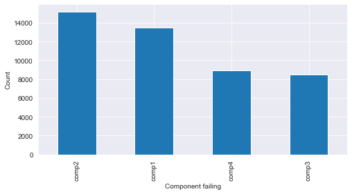

```python
sns.set_style("darkgrid")
plt.figure(figsize=(8, 4))
labeled_features['failure'].value_counts().plot(kind='bar')
plt.xlabel('Component failing')
plt.ylabel('Count')
```

Also, due to the class imbalance problem, it is important to look at evaluation metrics other than accuracy alone and compare those metrics to the baseline metrics which are computed when random chance is used to make predictions rather than a machine learning model. The comparison will bring out the value and benefits of using a machine learning model better.

## Summary

In this notebook, the steps of implementing a predictive maintenance model is provided using an example scenario where the goal is to predict failures due to certain components of a machine. Typical steps of predictive maintenance such as feature engineering, labelling, training and evaluation are explained using the example data sets. Predictive models are built both using Python packages and Azure Machine Learning Studio.